# BIOST 561: Homework 4

Due date: 7:00pm on **Wednesday**, May 29th, 2024

# Instructions

These instructions are essential, so please read them all carefully.

- Submit your homework on your GitHub page as the RMarkdown (`.Rmd`) and HTML files.
- Please answer the question prompt and show your code (inline). That is, all your code should be visible in the knitted chunks.
- To complete this homework, you may write in the `HW3.Rmd` file. (It is recommended to complete this homework in R Studio, where clicking the `Knit` button would knit your homework.)

# Disclosures

- Please disclose below who you collaborated with and if you’ve used ChatGPT (or any comparable AI tool) to what extent when completing this homework. See the syllabus for the course expectations.

# Note about the homework

**Note**: Most of your R code for this homework will **not** be in this homework. You mainly write `.R` files inside the `R` or `tests` folders. Therefore, you only need to show a little code inside this R Markdown file. You only need to write things inside this R Markdown file in the questions that explicitly ask you to do so.

Please use https://docs.google.com/document/d/1-ZTDPp39zbhsKbQ2FfBoCtiXKQj0jQSg75MAatYfiGI/edit?usp=sharing as a resource for this homework.

# Code of conduct for this homework

**Please be respectful to your peers** for this homework. Each student’s `compute_maximal_partial_clique()` function is anonymized and being used by every other student for this homework. Some implementations of this function work smoother than others. Nonetheless, 1) please be respectful to all the implementations throughout this homework, as you might not realize you’re talking to the author of an implementation, and 2) please do not feel embarrassed if you (knowing which implementation is yours, since you wrote it) does not work as well as you initially thought. Please do not try to “figure out” which student wrote which implementation.

I am **overwhelmingly confident** that you all wrote an implementation that suits your current comfort in R (which, of course, is different from student to student).

# Q1: Doing a code review of two other implementations

**Question 1B**: Looking at two implementations you were given, summarize what you think the implementations are doing in one to four sentences each. (This is to practice reading other people’s code.)

#### First Implementation: `compute_maximal_partial_clique19`

The `compute_maximal_partial_clique19` function seeks to find the largest partial clique within an adjacency matrix that meets a specified edge density threshold, alpha. It uses a greedy approach by first ordering nodes based on their degree and then iteratively building cliques starting from the highest degree nodes. At each step, it adds nodes to the current clique if the resulting submatrix meets the required edge density. The function continues this process to find and return the clique with the highest density that meets the alpha threshold. This method prioritizes nodes with higher connectivity to quickly build dense cliques.

#### Second Implementation: `compute_maximal_partial_clique23`

The compute_maximal_partial_clique23 function aims to identify the largest partial clique in a given adjacency matrix that meets a specified edge density, alpha. The function first verifies the validity of the input matrix and alpha using various checks. It then uses a backtracking approach to explore potential cliques, starting from an empty set and iteratively adding nodes. During this process, it ensures that the current subset of nodes maintains the required edge density. The largest valid clique found is returned along with its edge density.

**Question 1C** ### Recommendations for Improving Code Clarity

#### Second Implementation: `compute_maximal_partial_clique23`

1. **Variable Naming**: The function uses variables such as `curr_vertex`, `curr_clique`, and `next_vertex` within the `find_maximal_clique` function. These names are clear, but could be more descriptive. For instance, `curr_vertex` could be renamed to `current_node` and `curr_clique` to `current_clique_nodes` to improve readability.
2. **Function Factorization**: The function `is_partial_clique` is nested within the main function. It might be beneficial to move this out as a standalone helper function. This separation can make the code modular and easier to test individual components.

**Question 1D**:

#### First Implementation: `compute_maximal_partial_clique19`

```r
library(testthat)
test_that("returns empty for an empty clique", {
  res <- generate_partial_clique(n = 5, clique_fraction = 0, clique_edge_density = 0.5)
  result <- compute_maximal_partial_clique19(res$adj_mat, alpha = 0.5)
  expect_equal(result$clique_idx, integer(0))
  expect_equal(result$edge_density, 0)
})
```

```
#> -- Failure: returns empty for an empty clique ----------------------------------
#> result$clique_idx (`actual`) not equal to integer(0) (`expected`).
#>
#> `actual` is NULL
#> `expected` is an integer vector ()
#> Error:
#> ! Test failed
```

```r
test_that("identifies a full clique", {
  res <- generate_partial_clique(n = 5, clique_fraction = 1, clique_edge_density = 1)
  result <- compute_maximal_partial_clique19(res$adj_mat, alpha = 0.5)
  expect_equal(sort(result$clique_idx), 1:5)
  expect_equal(result$edge_density, 1)
})
```

```
#> Test passed
```

```r
test_that("finds clique at exact threshold", {
  res <- generate_partial_clique(n = 5, clique_fraction = 0.5, clique_edge_density = 1)
  result <- compute_maximal_partial_clique19(res$adj_mat, alpha = 0.5)
  expect_true(length(result$clique_idx) >= 2)  # Assuming clique of at least 2 nodes
  expect_true(result$edge_density >= 0.5)
})
```

```
#> Test passed
```

```r
test_that("identifies the correct clique among multiple possibilities", {
  n <- 10
  adj_mat <- matrix(0, nrow = n, ncol = n)
  diag(adj_mat) <- 1  # Diagonal elements should be 1

  # First clique: indices 1 to 5, intended lower density (won't meet alpha = 0.7)
  for (i in 1:5) {
    for (j in i:5) {
      if (i != j && runif(1) < 0.4) {  # Ensure i != j to skip diagonal, set lower density
        adj_mat[i, j] <- 1
        adj_mat[j, i] <- 1
      }
    }
  }

  # Second clique: indices 6 to 10, higher density (meets alpha = 0.7)
  for (i in 6:10) {
    for (j in i:10) {
      if (i != j && runif(1) < 0.8) {  # Ensure i != j to skip diagonal, set higher density
        adj_mat[i, j] <- 1
        adj_mat[j, i] <- 1
      }
    }
  }

  result <- compute_maximal_partial_clique19(adj_mat, alpha = 0.7)
  # Expect that the second clique is identified
  expect_true(all(result$clique_idx %in% 6:10))
  expect_true(result$edge_density >= 0.7)
})
```

```
#> Test passed
```

```r
test_that("performance on larger graphs", {
  res <- generate_partial_clique(n = 20, clique_fraction = 0.5, clique_edge_density = 0.5)
  system.time({
    result <- compute_maximal_partial_clique19(res$adj_mat, alpha = 0.5)
  }) -> time_taken
  expect_true(time_taken["elapsed"] < 10)  # Test should complete in less than 10 seconds
})
```

```
#> Test passed
```

#### Second Implementation: `compute_maximal_partial_clique23`

```r
library(testthat)
test_that("returns empty for an empty clique", {
  res <- generate_partial_clique(n = 5, clique_fraction = 0, clique_edge_density = 0.5)
  result <- compute_maximal_partial_clique23(res$adj_mat, alpha = 0.5)
  expect_equal(result$clique_idx, integer(0))
  expect_equal(result$edge_density, 0)
})
```

```
#> -- Failure: returns empty for an empty clique ----------------------------------
#> result$clique_idx (`actual`) not equal to integer(0) (`expected`).
#>
#>   `actual`: 5
#> `expected`:
#>
#> -- Failure: returns empty for an empty clique ----------------------------------
#> result$edge_density (`actual`) not equal to 0 (`expected`).
#>
#>   `actual`: NaN
#> `expected`:   0
#> Error:
#> ! Test failed
```

```r
test_that("identifies a full clique", {
  res <- generate_partial_clique(n = 5, clique_fraction = 1, clique_edge_density = 1)
  result <- compute_maximal_partial_clique23(res$adj_mat, alpha = 0.5)
  expect_equal(sort(result$clique_idx), 1:5)
  expect_equal(result$edge_density, 1)
})
```

```
#> Test passed
```

```r
test_that("finds clique at exact threshold", {
  res <- generate_partial_clique(n = 5, clique_fraction = 0.5, clique_edge_density = 1)
  result <- compute_maximal_partial_clique23(res$adj_mat, alpha = 0.5)
  expect_true(length(result$clique_idx) >= 2)  # Assuming clique of at least 2 nodes
  expect_true(result$edge_density >= 0.5)
})
```

```
#> Test passed
```

```r
test_that("identifies the correct clique among multiple possibilities", {
  n <- 10
  adj_mat <- matrix(0, nrow = n, ncol = n)
  diag(adj_mat) <- 1  # Diagonal elements should be 1

  # First clique: indices 1 to 5, intended lower density (won't meet alpha = 0.7)
  for (i in 1:5) {
    for (j in i:5) {
      if (i != j && runif(1) < 0.4) {  # Ensure i != j to skip diagonal, set lower density
        adj_mat[i, j] <- 1
        adj_mat[j, i] <- 1
      }
    }
  }

  # Second clique: indices 6 to 10, higher density (meets alpha = 0.7)
  for (i in 6:10) {
    for (j in i:10) {
      if (i != j && runif(1) < 0.8) {  # Ensure i != j to skip diagonal, set higher density
        adj_mat[i, j] <- 1
        adj_mat[j, i] <- 1
      }
    }
  }

  result <- compute_maximal_partial_clique23(adj_mat, alpha = 0.7)
  # Expect that the second clique is identified
  expect_true(all(result$clique_idx %in% 6:10))
  expect_true(result$edge_density >= 0.7)
})
```

```
#> -- Failure: identifies the correct clique among multiple possibilities ---------
#> all(result$clique_idx %in% 6:10) is not TRUE
#>
#> `actual`:   FALSE
#> `expected`: TRUE
#> Error:
#> ! Test failed
```

```r
test_that("performance on larger graphs", {
  res <- generate_partial_clique(n = 20, clique_fraction = 0.5, clique_edge_density = 0.5)
  system.time({
    result <- compute_maximal_partial_clique23(res$adj_mat, alpha = 0.5)
  }) -> time_taken
  expect_true(time_taken["elapsed"] < 10)  # Test should complete in less than 10 seconds
})
```

```
#> Test passed
```

# Q2: Constructing a simulation study

**Intent**: The intent of this question is to construct a simulation study that you’ll run on Bayes.

In this question, you’ll be designing a simulation. You will be doing this on Bayes for a couple of reasons: 1) To give you experience running code on Bayes, and 2) because your simulations might take a couple of hours to run.

Note: inside the file `compute_maximal_partial_clique_master.R` (which should now be in your `R` folder), I’ve provided you two functions: `compute_maximal_partial_clique_master()` and `compute_correct_density()`. You will find both functions useful for Q2 and Q3.

**Question 2A**: Please run the following code. If you cannot run it, something has gone wrong with your `UWBiost561` package. (For instance, it might be because your `generate_partial_clique()` function does not work or is not correctly located in your R package.)

```r
library(UWBiost561)
set.seed(10)
data <- UWBiost561::generate_partial_clique(n = 10,
                                            clique_fraction = 0.5,
                                            clique_edge_density = 0.95)

set.seed(10)
result1 <- UWBiost561::compute_maximal_partial_clique_master(
  adj_mat = data$adj_mat,
  alpha = 0.95,
  number = 11,
  time_limit = 10
)
result1

set.seed(10)
result2 <- UWBiost561::compute_maximal_partial_clique11(
  adj_mat = data$adj_mat,
  alpha = 0.95
)
result2
```

[output not shown]

Using the provided code as a framework, use the `compute_maximal_partial_clique_master()` with a setting of `time_limit` such that the function terminates prematurely, i.e., `time_limit` is set to be a small number. (That is, if, hypothetically, the function required 40 seconds to complete, but you set `time_limit` to only be 30 seconds.) By changing the ’ number ’ argument, you can use any implementation of `compute_maximal_partial_clique` you prefer for this question.

Note: For this question, you want to generate an adjacency matrix where `n` is large (i.e., a value close to 50), but `time_limit` is very small (i.e., just a few seconds). You deliberately want to cause a `timed_out` status.

**Question 2B**: I am going to use the demo simulation showed during Lecture 8.

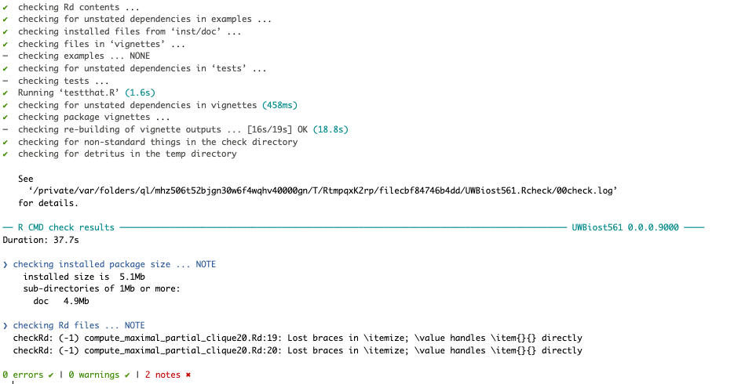

**Question 3E**:

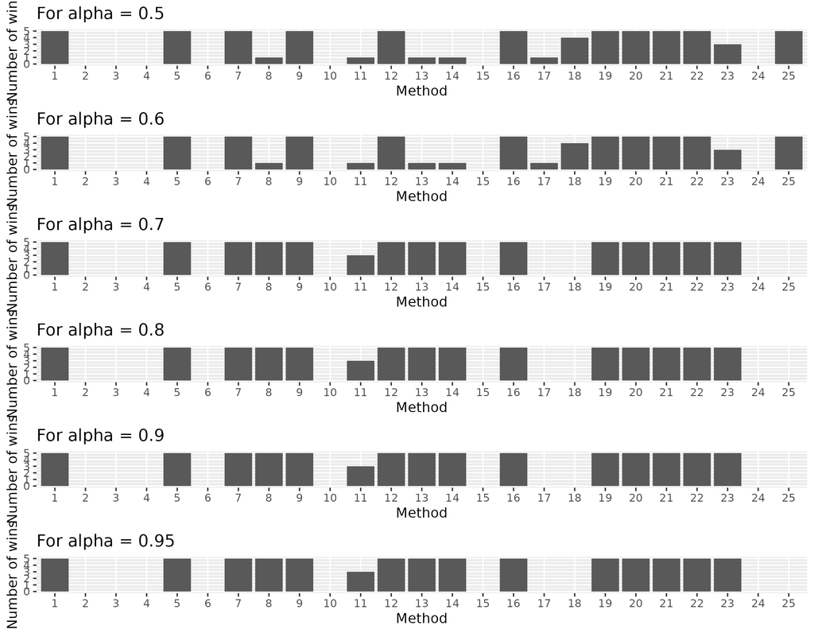

Figure 2: The first screenshot you are trying to reproduce (without the Sample watermark) in Question 3E.